# Fine-tunning T5 Model for Abstract Title Prediction

[figure not shown]

## **Fine-tunning T5 Model for Abstract Title Prediction** **© Mehdi Rezvandehy**

Summary

Python functions and data files to run this notebook are in my [Github](https://github.com/MehdiRezvandehy/Abstract-Title-Prediction-by-Fine-Tuned-T5.git)

```python
import warnings
warnings.filterwarnings('ignore')

from transformers import T5ForConditionalGeneration, T5Tokenizer # Similar to GPT2
from transformers import pipeline, T5ForConditionalGeneration, TrainingArguments
from transformers import Trainer, DataCollatorForSeq2Seq
import pandas as pd
pd.set_option('display.max_colwidth', -1)
from datasets import Dataset
import random
```

# Introduction

Instead of relying on only encoder or decoder, T5 has a complete end to end transformer (uses both encoder and decoder). Cross-attention bridges the gap between encoder and decoder. BERT derived from encoder part of transformer and where GPT is derived from decoder stack of transformer. There are proses and cons for each approach:

> **BERT**: it is faster natural language understanding tasks such as sequence and token classification but the flexibility of being able to create prompts and autoregressive use cases are lost.

> **GPT**: it is very flexible to teach for different domains, multiple type of tasks at once (sequence classification, summarization). However, generating text with GPT is very slow and is not robust enough to be used in classification task (like BERT).

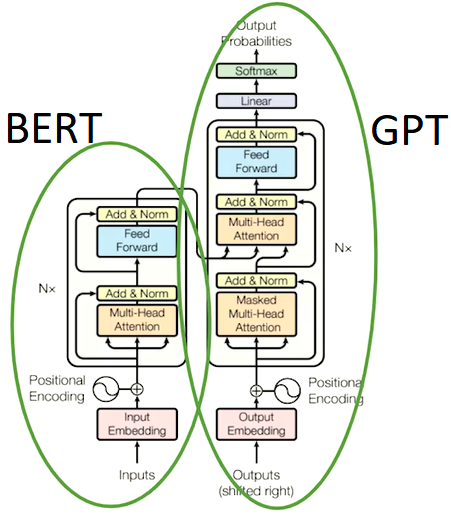

> **T5** uses both encoder and decoder stacks at the same time: it is is pure sequence to sequence model. T5 can apply multiple NLP tasks at once.

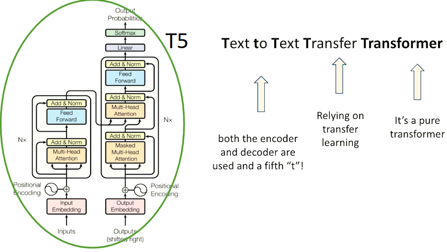

Image retrieved from [Sinan Ozdemir](https://learning.oreilly.com/videos/introduction-to-transformer/9780137923717/)

Figure below shows 4 of them:

1. `translate` English to German
2. `cola` means linguistic acceptability e.g. grammar
3. `stsb` semantic text similarity given two phrases how similar they are
4. `summarize` task. These four tasks can be done by T5 off the shelf. Each of these tasks comes with a prompt

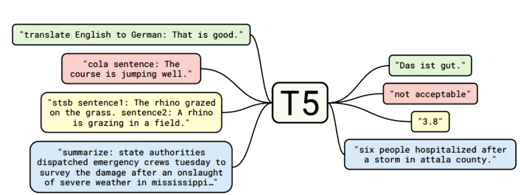

Image retrieved from [Sinan Ozdemir](https://learning.oreilly.com/videos/introduction-to-transformer/9780137923717/)

T5 was pre-trained on data set called common crawl (https://commoncrawl.org/).

**Sentinel tokens** are used similar to masking tasks to predict missing text. BERT is used masked language modeling but the biggest difference here is instead of masking single token and predicting it, T5 masks multiple tokens and predict them all

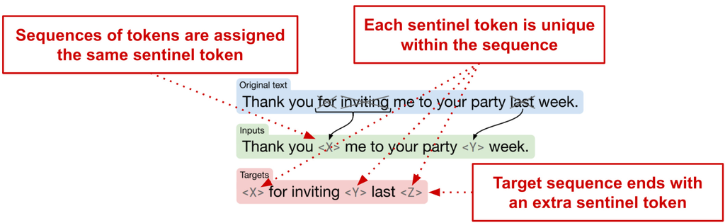

Three training objectives of T5 are:

1. casual (auto-regressive) language modeling: next word prediction
2. BERT-style objective: masking words and predicting the original text
3. Deshuffling: shuffling the input randomly and predicting the original text.

# Ready-made Results with T5

```python
t5_base_model = T5ForConditionalGeneration.from_pretrained('t5-base') # There are other flavour of T5
t5_base_tokenizer = T5Tokenizer.from_pretrained('t5-base')
```

## English to German Translation

```python
input_ids = t5_base_tokenizer.encode('translate English to German: How are you doing?', return_tensors='pt')

# translate
translate_ids = t5_base_model.generate(
    input_ids,
    num_beams=4,
    no_repeat_ngram_size=3,
    max_length=20,
    early_stopping=True
)

translate = t5_base_tokenizer.decode(translate_ids[0], skip_special_tokens=True)

print (f"Translated text:\n{translate}")
```

```
Translated text:
Wie geht es Ihnen?
```

```python
# pass labels in to calculate loss
ids = t5_base_tokenizer('translate English to German: How are you doing?', return_tensors='pt').input_ids
labels = t5_base_tokenizer('Wo ist die Schokolade?', return_tensors='pt').input_ids

loss = t5_base_model(input_ids=ids, labels=labels).loss

labels, loss
```

```
(tensor([[ 3488,   229,    67, 31267,    58,     1]]),
 tensor(4.0347, grad_fn=<NllLossBackward0>))
```

## Abstractive Summarization

Abstractive Summarization is a task creating a summary of a context without being constrained to use specific context of the subset.

```python
text ="""The transformer model is primarily based on the attention idea. In 2015, attention
mechanisms started to be used in NLP tasks and became the dominant way to perform NLP tasks
over the past decade. Attention in NLP is a mechanism designed to focus on specific parts of a
sequence in the context of another sequence. It is used to perform various NLP tasks, such as language
modeling, sequence classification, language translation, and image captioning. The idea behind attention
is to give the model the ability to attend to relevant information while performing a prediction task.
The attention mechanism allows the model to understand relationships between different elements in a sequence
and make predictions based on that information. For example, in language translation, the attention mechanism
helps the model understand which parts of a source sentence are relevant for translating into a target language.
There are various types of attention mechanisms, including self-attention, which is the kind of attention that
powers the transformer architecture in NLP.
"""

preprocessed_text = text.strip().replace("\n","")

print ("preprocessed text :\n", preprocessed_text)
```

```
preprocessed text :
 The transformer model is primarily based on the attention idea. In 2015, attention mechanisms started to be used in NLP tasks and became the dominant way to perform NLP tasks over the past decade. Attention in NLP is a mechanism designed to focus on specific parts of a sequence in the context of an…
```

Making a summarization prompt with T5; it has benefit of multi-task learning. For example, for BERT, we have to change the architect of layers to perform a NLP task. It is not multi-task oriented. GPT is multi-task oriented, we should prompt an input sequence that GPT has an idea about the task. However, T5 can do this with minor implementation. For T5, we only need to place the prompt at the beginning of the task whereas for GPT we also need to add token at the end.

```python
# We only need to add "summarize: " at the beginning to apply text summerization
t5_prepared_text = "summarize: " + preprocessed_text

ids = t5_base_tokenizer.encode(t5_prepared_text, return_tensors="pt") # encode the phrase

# summmarize
summmarize = t5_base_model.generate(ids,num_beams=4,no_repeat_ngram_size=3, # num_beams to make prediction less random
                                     min_length=10,max_length=30,early_stopping=True
                                     )

summarized = t5_base_tokenizer.decode(summmarize[0], skip_special_tokens=True)

print (f"The Summarized text is: \n{summarized}")
```

```
The Summarized text is:
attention mechanisms started to be used in NLP tasks in 2015. it is a mechanism designed to focus on specific parts of a sequence
```

```python
text ="""There are many approaches that use weak-supervision to train networks to
segment 2D images. By contrast, existing 3D approaches rely on full-supervision
of a subset of 2D slices of the 3D image volume. In this paper, we propose an
approach that is truly weakly-supervised in the sense that we only need to
provide a sparse set of 3D point on the surface of target objects, an easy task
that can be quickly done. We use the 3D points to deform a 3D template so that
it roughly matches the target object outlines and we introduce an architecture
that exploits the supervision provided by coarse template to train a network to
find accurate boundaries. We evaluate the performance of our approach on Computed Tomography (CT),
Magnetic Resonance Imagery (MRI) and Electron Microscopy (EM) image datasets.
We will show that it outperforms a more traditional approach to
weak-supervision in 3D at a reduced supervision cost."""

preprocessed_text = text.strip().replace("\n","")

# We only need to add "Make title: " at the beginning to apply text summerization
t5_prepared_text = "extract labels: " + preprocessed_text

ids = t5_base_tokenizer.encode(t5_prepared_text, return_tensors="pt") # encode the phrase

# summmarize
summmarize = t5_base_model.generate(ids,num_beams=4,no_repeat_ngram_size=3, # num_beams to make prediction less random
                                     min_length=10,max_length=20,early_stopping=True
                                     )

summarized = t5_base_tokenizer.decode(summmarize[0], skip_special_tokens=True)

print (f"The title of the text is: \n{summarized}")
```

```
The title of the text is:
Falk: weakly-supervised approach to train networks tosegment 2D images
```

## `CoLA`: The Corpus of Linguistic Acceptability

CoLA (Corpus of Linguistic Acceptability) is for checking grammatical correctess.

```python
ids = t5_base_tokenizer.encode('cola sentence: How are you doing?', return_tensors='pt')

# CoLA
translate_ids = t5_base_model.generate(ids,num_beams=4,no_repeat_ngram_size=3,
                                       max_length=20,early_stopping=True)

translate = t5_base_tokenizer.decode(translate_ids[0], skip_special_tokens=True)

print(f"is grammatically correct?: \n{translate}")
```

```
is grammatically correct?:
acceptable
```

```python
input_ids = t5_base_tokenizer.encode('cola sentence: How are you doings?', return_tensors='pt')

# summmarize
translate_ids = t5_base_model.generate(
    input_ids,
    max_length=20,
    early_stopping=True
)

output = t5_base_tokenizer.decode(translate_ids[0], skip_special_tokens=True)

print(f"is grammatically correct?: \n{output}")
```

```
is grammatically correct?:
unacceptable
```

## Q/A - Question/Answering

Extractive Q/A can be applied by BERT and abstractive Q/A with GPT. T5 (Text-to-Text Transfer Transformer) can be used for abstractive question answering. In the context of question answering, the input can be a question, and the target can be the corresponding answer.

```python
ids = t5_base_tokenizer.encode(
    'question: Where does I work? context: I live in Alberta but work in Calgary.', return_tensors='pt'
)

# Q/A
translate_ids = t5_base_model.generate(ids,early_stopping=True)

result = t5_base_tokenizer.decode(translate_ids[0], skip_special_tokens=True)

print(f"result: \n{result}")
```

```
result:
Calgary
```

## `STSB` - Semantic Text Similarity Benchmark

`STSB` calculates the similarity between two sentences from 0 to 5 scale.

```python
sentence_one = 'Python is scary animal'
sentence_two = 'I love coding with Python'

ids = t5_base_tokenizer.encode(f"stsb sentence1: {sentence_one} sentence2: {sentence_two}", return_tensors='pt')

# calculate semantic similarity
translate_ids = t5_base_model.generate(ids, max_length=3, early_stopping=True)

result = t5_base_tokenizer.decode(translate_ids[0], skip_special_tokens=True)

print(f"semantically similar? (0-5): \n{result}")
```

```
semantically similar? (0-5):
1.0
```

```python
sentence_one = 'President greets the press in Chicago'
sentence_two = 'Biden speaks to media in Illinois'

ids = t5_base_tokenizer.encode(f"stsb sentence1: {sentence_one} sentence2: {sentence_two}", return_tensors='pt')

# calculate semantic similarity
translate_ids = t5_base_model.generate(ids, max_length=3, early_stopping=True)

result = t5_base_tokenizer.decode(translate_ids[0], skip_special_tokens=True)

print(f"semantically similar? (0-5): \n{result}")
```

```
semantically similar? (0-5):
1.6
```

## `MNLI` - Multi-Genre Natural Language Inference

Multi-Genre Natural Language Inference refers to a challenging task in natural language processing where a model is trained to determine the logical relationship between pairs of sentences, but with a focus on handling diverse genres or writing styles. This involves developing models that can effectively understand and infer **entailment**, **contradiction**, or **neutral** across various types of textual content, enhancing their applicability in a wide range of language understanding tasks.

```python
ids = t5_base_tokenizer.encode(
    'mnli premise: I am going to medical school. hypothesis: I will be an Engineer', return_tensors='pt')

# mnli
translate_ids = t5_base_model.generate(ids,early_stopping=True)

result = t5_base_tokenizer.decode(translate_ids[0], skip_special_tokens=True)

print(f"Result: \n{result}")
```

```
Result:
contradiction
```

```python
ids = t5_base_tokenizer.encode(
    'mnli premise: I am going to medical school. hypothesis: I am going to be a physician', return_tensors='pt')

# mnli
translate_ids = t5_base_model.generate(ids,early_stopping=True)

result = t5_base_tokenizer.decode(translate_ids[0], skip_special_tokens=True)

print(f"Result: \n{result}")
```

```
Result:
entailment
```

```python
ids = t5_base_tokenizer.encode(
    'mnli premise: I am going to medical school. hypothesis: I will be top 2 student in my class', return_tensors='pt')

# mnli
translate_ids = t5_base_model.generate(ids,early_stopping=True)

result = t5_base_tokenizer.decode(translate_ids[0], skip_special_tokens=True)

print(f"Result: \n{result}")
```

```
Result:
neutral
```

Off-shelf results with T5 cannot be used in production; we can only use them as baseline prediction. T5 should be fine-tuned for models in production.

# Fine-tune T5 for Abstractive Summarization

## [arXiv Paper Abstracts](https://www.kaggle.com/datasets/spsayakpaul/arxiv-paper-abstracts) Data set

Paper submission systems (CMT, OpenReview, etc.) require the users to upload paper titles and paper abstracts and then specify the subject areas their papers best belong to. Won't it be nice if such submission systems provided viable subject area suggestions as to where the corresponding papers could be best associated with?

This dataset would allow developers to build baseline models that might benefit this use case. Data analysts might also enjoy analyzing the intricacies of different papers and how well their abstracts correlate to their noted categories. Additionally, we hope that the dataset will serve as a decent benchmark for building useful text classification systems.

```python
base_model = T5ForConditionalGeneration.from_pretrained('t5-small')
base_tokenizer = T5Tokenizer.from_pretrained('t5-small')
```

```python
df = pd.read_csv('arxiv_data.csv',encoding='latin-1')

df = df[["summaries","titles"]]
df = df.dropna()
print(df.shape)

# Set aside some data as holdout set
Holdout = df[-100:]

# Since the data is big for fine-tunning, 10000 of samples are selected.
df = df[:10000].copy()


df.head(2)
```

```
(51774, 2)
```

|  | summaries | titles |
| --- | --- | --- |
| 0 | Stereo matching is one of the widely used techniques for inferring depth from\nstereo images owing to its robustness and speed. It has become one of the major\ntopics of research since it finds its ap… | Survey on Semantic Stereo Matching / Semantic Depth Estimation |
| 1 | The recent advancements in artificial intelligence (AI) combined with the\nextensive amount of data generated by today's clinical systems, has led to the\ndevelopment of imaging AI solutions across th… | FUTURE-AI: Guiding Principles and Consensus Recommendations for Trustworthy Artificial Intelligence in Future Medical Imaging |

## Split train and test set

```python
df = df[ (df['summaries'].str.len() >=30)]
df.shape
```

```
(10000, 2)
```

```python
# Pre-processing step
# Punctuation is important in grammar and important for complex decoding architectures to know when to stop!
def add_punc(s):
    if s[-1] not in ('.', '!', '?'):
        s = s + '.'
    return s

df.dropna(inplace=True)

df['summaries'] = df['summaries'].map(add_punc)

print(df.shape)

df.head(2)
```

```
(10000, 2)
```

|  | summaries | titles |
| --- | --- | --- |
| 0 | Stereo matching is one of the widely used techniques for inferring depth from\nstereo images owing to its robustness and speed. It has become one of the major\ntopics of research since it finds its ap… | Survey on Semantic Stereo Matching / Semantic Depth Estimation |
| 1 | The recent advancements in artificial intelligence (AI) combined with the\nextensive amount of data generated by today's clinical systems, has led to the\ndevelopment of imaging AI solutions across th… | FUTURE-AI: Guiding Principles and Consensus Recommendations for Trustworthy Artificial Intelligence in Future Medical Imaging |

```python
random.seed(20)

paper_title = Dataset.from_pandas(df[:2000])

# Set aside some data as holdout set
Holdout = df[-100:]
```

```python
# We have a prompt but only as a prefix in the encoder
prefix = "title: "

# Manually add our own labels because unlike GPT,
# we cannot assume the labels are based on the inputs
def preprocess_function(examples):
    inputs = [prefix + doc for doc in examples["summaries"]]
    model_inputs = base_tokenizer(inputs, max_length=1024, truncation=True)

    labels = base_tokenizer(examples["titles"], max_length=128, truncation=True)

    model_inputs["labels"] = labels["input_ids"]
    return model_inputs
```

```python
paper_title = paper_title.map(preprocess_function, batched=True)
```

```python
paper_title[0]
```

[output not shown]

[output cut: 299 more lines]

```
  1225,
  30535,
  12296,
  53,
  3,
  87,
  679,
  348,
  1225,
  25734,
  107,
  23621,
  23,
  106,
  1]}
```

```python
paper_title = paper_title.train_test_split(test_size=.1)
paper_title
```

```
DatasetDict({
    train: Dataset({
        features: ['summaries', 'titles', '__index_level_0__', 'input_ids', 'attention_mask', 'labels'],
        num_rows: 1800
    })
    test: Dataset({
        features: ['summaries', 'titles', '__index_level_0__', 'input_ids', 'attention_mask', 'labels'],
        num_rows: 200
    })
})
```

```python
# Data collator specifically for generic sequence to sequence tasks
# Use when we are translating one sequence to another like translation, summarization, etc
data_collator = DataCollatorForSeq2Seq(tokenizer=base_tokenizer, model=base_model)
```